# Regularization is a technique used to reduce the errors by fitting the function appropriately on the given training set and avoid overfitting.

L1 regularization

Minimization objective = LS Obj + α * (sum of absolute value of coefficients)

L2 regularization

βridge=(X′X+λI)−1(X′Y)

- I denotes the identity matrix.
- The λ parameter is the regularization penalty.

A regression model which uses L1 Regularization technique is called

LASSO(Least Absolute Shrinkage and Selection Operator) regression.

A regression model that uses L2 regularization technique is called Ridge regression.

Lasso Regression adds “absolute value of magnitude” of coefficient as penalty term to the loss function(L).

# Advantages

1. Avoids overfitting a model.
1. They does not require unbiased estimators.
1. The ridge estimator is preferably good at improving the least-squares estimate when there is multicollinearity.
1. They add just enough bias to make the estimates reasonably reliable approximations to true population values.

# Disadvantages

1.They include all the predictors in the final model.

2.They shrink the coefficients towards zero.

3.They trade the variance for bias.

```python
import pandas as pd
import numpy  as np
import seaborn as sns
import matplotlib.pyplot as plt
import warnings
warnings.filterwarnings('ignore')
```

```python
df=pd.read_csv('cars.csv')
```

```python
df.info()
```

```
<class 'pandas.core.frame.DataFrame'>
RangeIndex: 205 entries, 0 to 204
Data columns (total 15 columns):
 #   Column             Non-Null Count  Dtype
---  ------             --------------  -----
 0   symboling          205 non-null    int64
 1   normalized-losses  205 non-null    object
 2   make               205 non-null    object
 3   fuel-type          205 non-null    object
 4   body-style         205 non-null    object
 5   drive-wheels       205 non-null    object
 6   engine-location    205 non-null    object
 7   width              205 non-null    float64
 8   height             205 non-null    float64
 9   engine-type        205 non-null    object
 10  engine-size        205 non-null    int64
 11  horsepower         205 non-null    object
 12  city-mpg           205 non-null    int64
 13  highway-mpg        205 non-null    int64
 14  price              205 non-null    int64
dtypes: float64(2), int64(5), object(8)
memory usage: 24.1+ KB
```

```python
df.head()
```

|  | symboling | normalized-losses | make | fuel-type | body-style | drive-wheels | engine-location | width | height | engine-type | engine-size | horsepower | city-mpg | highway-mpg | price |
| --- | --- | --- | --- | --- | --- | --- | --- | --- | --- | --- | --- | --- | --- | --- | --- |
| 0 | 3 | ? | alfa-romero | gas | convertible | rwd | front | 64.1 | 48.8 | dohc | 130 | 111 | 21 | 27 | 13495 |
| 1 | 3 | ? | alfa-romero | gas | convertible | rwd | front | 64.1 | 48.8 | dohc | 130 | 111 | 21 | 27 | 16500 |
| 2 | 1 | ? | alfa-romero | gas | hatchback | rwd | front | 65.5 | 52.4 | ohcv | 152 | 154 | 19 | 26 | 16500 |
| 3 | 2 | 164 | audi | gas | sedan | fwd | front | 66.2 | 54.3 | ohc | 109 | 102 | 24 | 30 | 13950 |
| 4 | 2 | 164 | audi | gas | sedan | 4wd | front | 66.4 | 54.3 | ohc | 136 | 115 | 18 | 22 | 17450 |

```python
df['normalized-losses'].replace('?',np.nan,inplace=True)
df['normalized-losses']=df['normalized-losses'].astype(float)
nlm=df['normalized-losses'].mean()
df['normalized-losses'].fillna(nlm,inplace=True)
```

```python
df['horsepower'].replace('?',np.nan,inplace=True)
df['horsepower']=df['horsepower'].astype(float)
nlm=df['horsepower'].mean()
df['horsepower'].fillna(nlm,inplace=True)
```

```python
df.info()
```

```
<class 'pandas.core.frame.DataFrame'>
RangeIndex: 205 entries, 0 to 204
Data columns (total 15 columns):
 #   Column             Non-Null Count  Dtype
---  ------             --------------  -----
 0   symboling          205 non-null    int64
 1   normalized-losses  205 non-null    float64
 2   make               205 non-null    object
 3   fuel-type          205 non-null    object
 4   body-style         205 non-null    object
 5   drive-wheels       205 non-null    object
 6   engine-location    205 non-null    object
 7   width              205 non-null    float64
 8   height             205 non-null    float64
 9   engine-type        205 non-null    object
 10  engine-size        205 non-null    int64
 11  horsepower         205 non-null    float64
 12  city-mpg           205 non-null    int64
 13  highway-mpg        205 non-null    int64
 14  price              205 non-null    int64
dtypes: float64(4), int64(5), object(6)
memory usage: 24.1+ KB
```

```python
df_cat=df.select_dtypes(object)
df_num=df.select_dtypes(['int64','float'])
```

```python
from sklearn.preprocessing import LabelEncoder
```

```python
for col in df_cat:
    lb=LabelEncoder()
    df_cat[col]=lb.fit_transform(df_cat[col])
```

```python
df=pd.concat([df_cat,df_num],axis=1)
df.describe()
```

|  | make | fuel-type | body-style | drive-wheels | engine-location | engine-type | symboling | normalized-losses | width | height | engine-size | horsepower | city-mpg | highway-mpg | price |
| --- | --- | --- | --- | --- | --- | --- | --- | --- | --- | --- | --- | --- | --- | --- | --- |
| count | 205.000000 | 205.000000 | 205.000000 | 205.000000 | 205.000000 | 205.000000 | 205.000000 | 205.000000 | 205.000000 | 205.000000 | 205.000000 | 205.000000 | 205.000000 | 205.000000 | 205.000000 |
| mean | 12.195122 | 0.902439 | 2.614634 | 1.326829 | 0.014634 | 3.014634 | 0.834146 | 122.000000 | 65.907805 | 53.724878 | 126.907317 | 104.256158 | 25.219512 | 30.751220 | 13227.478049 |
| std | 6.274831 | 0.297446 | 0.859081 | 0.556171 | 0.120377 | 1.054765 | 1.245307 | 31.681008 | 2.145204 | 2.443522 | 41.642693 | 39.519211 | 6.542142 | 6.886443 | 7902.651615 |
| min | 0.000000 | 0.000000 | 0.000000 | 0.000000 | 0.000000 | 0.000000 | -2.000000 | 65.000000 | 60.300000 | 47.800000 | 61.000000 | 48.000000 | 13.000000 | 16.000000 | 5118.000000 |
| 25% | 8.000000 | 1.000000 | 2.000000 | 1.000000 | 0.000000 | 3.000000 | 0.000000 | 101.000000 | 64.100000 | 52.000000 | 97.000000 | 70.000000 | 19.000000 | 25.000000 | 7788.000000 |
| 50% | 12.000000 | 1.000000 | 3.000000 | 1.000000 | 0.000000 | 3.000000 | 1.000000 | 122.000000 | 65.500000 | 54.100000 | 120.000000 | 95.000000 | 24.000000 | 30.000000 | 10345.000000 |
| 75% | 19.000000 | 1.000000 | 3.000000 | 2.000000 | 0.000000 | 3.000000 | 2.000000 | 137.000000 | 66.900000 | 55.500000 | 141.000000 | 116.000000 | 30.000000 | 34.000000 | 16500.000000 |
| max | 21.000000 | 1.000000 | 4.000000 | 2.000000 | 1.000000 | 6.000000 | 3.000000 | 256.000000 | 72.300000 | 59.800000 | 326.000000 | 288.000000 | 49.000000 | 54.000000 | 45400.000000 |

```python
x=df.iloc[:,:-1]
y=df.iloc[:,-1]
```

```python
from sklearn.model_selection import train_test_split as t
xtrain,xtest,ytrain,ytest=t(x,y,random_state=1)
```

```python
from sklearn.linear_model import LinearRegression as linreg
from sklearn.metrics import r2_score  as r2,mean_squared_error as mse ,accuracy_score as ac
```

```python
lr=linreg()
lr.fit(xtrain,ytrain)
ypred=lr.predict(xtest)
print(f' accuracy {r2(ytest,ypred)*100}')
print(f'  rmse     {np.sqrt(mse(ytest,ypred))*100}')
```

```
 accuracy 81.74935371483143
  rmse     349685.6374302878
```

```python
xtrain,xtest,ytrain,ytest=t(x,y,random_state=156)
lr=linreg()
lr.fit(xtrain,ytrain)
ypred=lr.predict(xtest)
print(f'  accuracy       {r2(ytest,ypred)*100}')
print(f'  rmse     {np.sqrt(mse(ytest,ypred))*100}')
```

```
  accuracy       90.83497619577983
  rmse     260284.19337298637
```

```python
from sklearn.linear_model import Lasso as l,Ridge as r
```

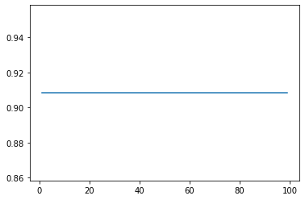

```python
ac=[]
for i in range(1,100):
    l1=l(alpha=i,random_state=1)
    l1.fit(xtrain,ytrain)
    lypred=l1.predict(xtest)
    ac.append(r2(ytest,ypred))
plt.plot(range(1,100),ac)
plt.show()
```

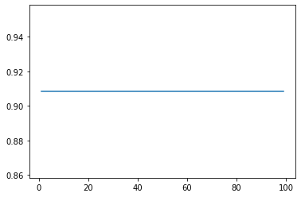

```python
ac=[]
for i in range(1,100):
    l1=l(alpha=1,random_state=i)
    l1.fit(xtrain,ytrain)
    lypred=l1.predict(xtest)
    ac.append(r2(ytest,ypred))
plt.plot(range(1,100),ac)
plt.show()
```

```python
l1=l(alpha=1,random_state=i)
l1.fit(xtrain,ytrain)
lypred=l1.predict(xtest)
print(r2(ytest,lypred)*100)
```

```
90.83325932329973
```

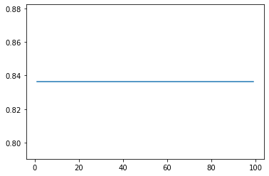

```python
ac=[]
for i in range(1,100):
    l2=r(alpha=10)
    l2.fit(xtrain,ytrain)
    l2ypred=l2.predict(xtest)
    ac.append(r2(ytest,l2ypred))
plt.plot(range(1,100),ac)
```

```python
l2=r(alpha=10)
l2.fit(xtrain,ytrain)
l2ypred=l2.predict(xtest)
print(r2(ytest,l2ypred)*100)
```

```
83.63523911863774
```

From both l1 and l2 reguralization we can say l1 is giving more accuracy

that is 90.83325932329973